# NIRx Classification Task

## Author: Flynn Alexander

### Project Task

The project is to develop a predictive model based on fNIRS data. You will use widely available fNIRS data taken during a finger tapping task. In this experiment, 5 participants were asked to tap their left and right finger at separate times. Using the fNIRS data collected during the experiment, determine what features of the fNIRS response during left finger tapping are good predictors of the fNIRS response during right finger tapping.

You will be using the MNE-NIRS toolbox in python to create this model. You may start from the code provided in this example for performing the fNIRS preprocessing but are free to use any other Python toolboxes to complete the task. The example also contains the code required to load the dataset. You should present your work in a Jupyter Notebook.

# Solution Start:

## Imports

```python
from itertools import compress
import matplotlib.pyplot as plt
import numpy as np
import mne
from collections import Counter
import torch
import torch.nn as nn
import torch.nn.functional as F
from torch.utils.data import DataLoader, TensorDataset
from sklearn.model_selection import train_test_split, KFold
import wandb
from tqdm import tqdm
```

## Data Import from MNE

One of the trickiest parts about data prep can be using third-party packages to get the data in the first place. At first, I had some grief understanding the custom object they use to store raw information from the NIRx device; this is primarily what slowed me down during the meeting yesterday. NIRx keeps its raw data in a mne.io.nirx.nirx.RawNIRX object. This object has a lot of useful preprocessing functions available, but this format is unsuitable for ML, and I needed to prioritise getting clean information into tensors. This will also make the data more interpretable for analysis.

I followed through with all the steps for cleaning and processing as outlined in their documentation and examples.

```python
# Import raw data
fnirs_data_folder = mne.datasets.fnirs_motor.data_path()
fnirs_cw_amplitude_dir = fnirs_data_folder / "Participant-1"
raw_intensity = mne.io.read_raw_nirx(fnirs_cw_amplitude_dir, verbose=True)
raw_intensity.load_data()

# Set the duration, rename the trigger codes, and remove trigger code 15 which indicates start/stop of experimentation
raw_intensity.annotations.set_durations(5)
event_mapping = {"1.0": "Control", "2.0": "Tapping/Left", "3.0": "Tapping/Right"}
raw_intensity.annotations.rename(event_mapping)
unwanted = np.nonzero(raw_intensity.annotations.description == "15.0")
raw_intensity.annotations.delete(unwanted)

# Remove channels where the optodes are too close together (less than 1 cm between optodes)
picks = mne.pick_types(raw_intensity.info, meg=False, fnirs=True)
dists = mne.preprocessing.nirs.source_detector_distances(raw_intensity.info, picks=picks)
raw_intensity.pick(picks[dists > 0.01])

# Convert the raw intensity data to optical density (need clarification on this?)
raw_od = mne.preprocessing.nirs.optical_density(raw_intensity)

# Apply scalp coupling index (SCI) to remove bad channels
# This process involves looking for the presence of cardiac oscillations in the data (need clarification on this?)
sci = mne.preprocessing.nirs.scalp_coupling_index(raw_od)
raw_od.info["bads"] = list(compress(raw_od.ch_names, sci < 0.5))

# Convert the optical density data to haemoglobin concentration using the MBLL method
raw_haemo = mne.preprocessing.nirs.beer_lambert_law(raw_od, ppf=0.1)

# Remove heart rate using a low pass filter, and slow drifts using a high pass filter (need clarification about this)
raw_haemo_unfiltered = raw_haemo.copy()
raw_haemo.filter(0.05, 0.7, h_trans_bandwidth=0.2, l_trans_bandwidth=0.02)

# Extract epochs from the data related to each of the experimental conditions
events, event_dict = mne.events_from_annotations(raw_haemo)

# Define the rejection criteria, baseline correction, and extract the epochs
reject_criteria = dict(hbo=80e-6)
tmin, tmax = -5, 15
epochs = mne.Epochs(
    raw_haemo,
    events,
    event_id=event_dict,
    tmin=tmin,
    tmax=tmax,
    reject=reject_criteria,
    reject_by_annotation=True,
    proj=True,
    baseline=(None, 0),
    preload=True,
    detrend=None,
    verbose=True,
)
```

```
Loading /Users/flynnalexander/mne_data/MNE-fNIRS-motor-data/Participant-1
Reading 0 ... 23238  =      0.000 ...  2974.464 secs...
Filtering raw data in 1 contiguous segment
Setting up band-pass filter from 0.05 - 0.7 Hz

FIR filter parameters
---------------------
Designing a one-pass, zero-phase, non-causal bandpass filter:
- Windowed time-domain design (firwin) method
- Hamming window with 0.0194 passband ripple and 53 dB stopband attenuation
- Lower passband edge: 0.05
- Lower transition bandwidth: 0.02 Hz (-6 dB cutoff frequency: 0.04 Hz)
- Upper passband edge: 0.70 Hz
- Upper transition bandwidth: 0.20 Hz (-6 dB cutoff frequency: 0.80 Hz)
- Filter length: 1291 samples (165.248 s)

Used Annotations descriptions: ['Control', 'Tapping/Left', 'Tapping/Right']
Not setting metadata
90 matching events found
Setting baseline interval to [-4.992, 0.0] s
Applying baseline correction (mode: mean)
0 projection items activated
Using data from preloaded Raw for 90 events and 157 original time points ...
    Rejecting  epoch based on HBO : ['S4_D4 hbo']
    Rejecting  epoch based on HBO : ['S4_D4 hbo', 'S8_D8 hbo']
    Rejecting  epoch based on HBO : ['S4_D4 hbo']
    Rejecting  epoch based on HBO : ['S4_D4 hbo', 'S8_D8 hbo']
    Rejecting  epoch based on HBO : ['S1_D1 hbo', 'S3_D3 hbo', 'S4_D4 hbo', 'S7_D6 hbo', 'S7_D7 hbo', 'S8_D8 hbo']
    Rejecting  epoch based on HBO : ['S4_D4 hbo', 'S6_D8 hbo', 'S8_D8 hbo']
6 bad epochs dropped
```

```
[Parallel(n_jobs=1)]: Done  17 tasks      | elapsed:    0.0s
```

Finally, the data is split into respective epochs. Each epoch is a chunk of sample data where the participant was either doing nothing, tapping their left thumb, or tapping their right thumb. Each chunk is approximately 20 seconds long and includes sensor information from every available channel.

## Further Cleaning and Investigation

Now that MNE's preprocessing has been applied, we prepare the data for ML applications.

Firstly, I extract the information into raw numpy arrays of shape (n_epochs, n_channels, n_timesteps). Because the number of timesteps is a constant, we can take advantage of that and elegantly store the information in a 3D array. We should also grab the labels for the epochs and the channel names (channel names will help us understand the formatting).

Given the number of dimensions and scale of this data, in-depth analysis for trends is better suited to a robust ML approach. I will attempt to fit a neural network to make predictions using this data.

```python
all_epochs = epochs.get_data(copy=False)
print(all_epochs.shape)

epoch_num_labels = epochs.events[:, -1]  # The last column of the events array contains the event IDs
epoch_str_labels = [event_mapping[str(float(label))] for label in epoch_num_labels]  # Convert event IDs to labels
epoch_num_labels = epoch_num_labels - 1 # In Pytorch we want our labels to start from 0 not 1

channel_names = epochs.ch_names # The names of the channels used in the experiment
print(channel_names[:10])
```

```
(84, 40, 157)
['S1_D1 hbo', 'S1_D1 hbr', 'S1_D2 hbo', 'S1_D2 hbr', 'S1_D3 hbo', 'S1_D3 hbr', 'S2_D1 hbo', 'S2_D1 hbr', 'S2_D3 hbo', 'S2_D3 hbr']
```

We can see that the all_epochs array is formatted using 84 epochs, 40 channels, and 157 timesteps (spread over 20-second chunks). As we can see above, the channels are stored in alternating order of HBO and HBR, which will be an essential point when formatting the data later.

We know that 6 of the epochs were removed during the MNE preprocessing. It's important that we look over the distribution of labels to understand the size and spread of our population data. We may need to alter the training data if it is unbalanced.

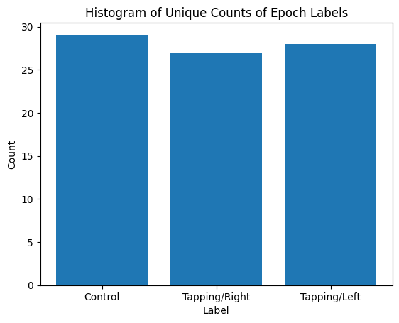

```python
unique_count = (Counter(epoch_str_labels))
# Separate keys and values for plotting
labels, values = zip(*unique_count.items())
plt.bar(labels, values)
plt.title('Histogram of Unique Counts of Epoch Labels')
plt.xlabel('Label')
plt.ylabel('Count')
plt.show()
```

Although it is a relatively small dataset for ML applications, it is well-balanced, and the difference in signals between control and tapping was easily distinguishable when observed in the source documentation (reference image below). This gives me the confidence to continue and attempt to fit a model without adjusting the size of the dataset.

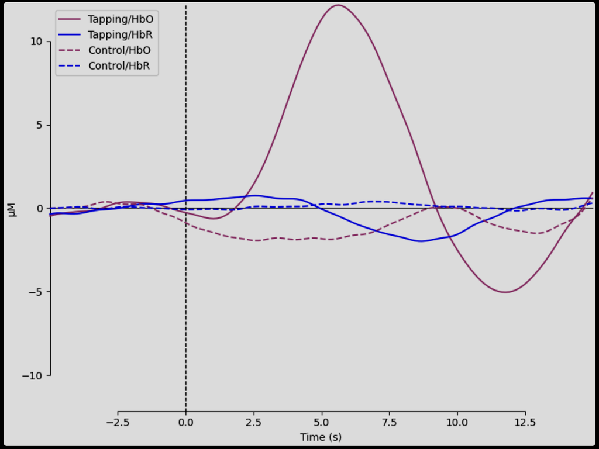

Given the smaller data set size (84 epochs in total), we will use Kfold cross-validation to validate that our model performance is stable when trained upon different samples from the population. We may also need to use data augmentation, dropout, and normalisation to prevent overfitting and improve the model's ability to train via gradient descent.

Now, let's focus on the data formatting required for model training. I want to take advantage of the current data structure and the fact that each epoch consists of 40 channels and 157 timesteps. We also know that the 40 channels can be split into two 20-channel groups for HBO and HBR.

If we apply a convolutional neural network to this problem, we could imagine the data formatted in a structure such as (2 layers, 20 channels, 157 timesteps); this essentially creates two temporal images similar to those shown in the MNE documentation. Separating the HBO and HBR is important because we wouldn't want the kernel to convolve over the HBO and HBR together. This would be like getting a kernel to convolve over a combination of red and green in an RGB image rather than the three separate channels individually. A diagram of this structure is shown below.

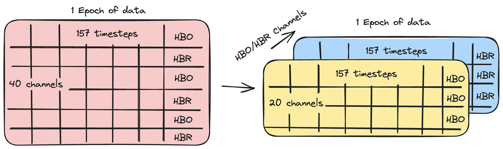

Observing the distributions of values for HBO and HBR is also important. We know that they can report values at different magnitudes and scales as the brain is stimulated. Machine learning typically requires normalised inputs to best take advantage of gradient descent for model training. Let's look at this now.

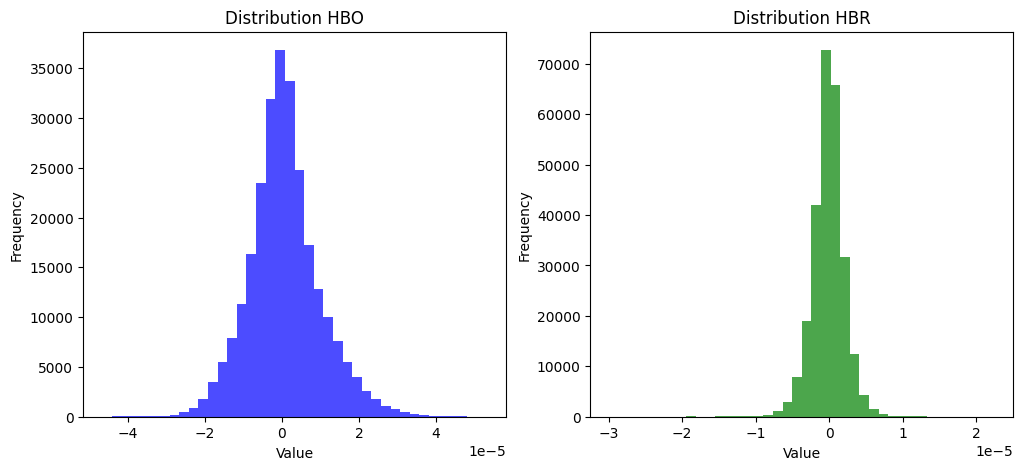

```python
all_epochs_hbo = all_epochs[:, 0::2, :]  # Select every second channel starting from the first (HBO)
all_epochs_hbr = all_epochs[:, 1::2, :]  # Select every second channel starting from the second (HBR)
channel_names_hbo = channel_names[0::2]  # Select every second channel name starting from the first (HBO)
channel_names_hbr = channel_names[1::2]  # Select every second channel name starting from the second (HBR)

# Investigate the distribution of data for HBO and HBR
hbo_1D = all_epochs_hbo.flatten()
hbr_1D = all_epochs_hbr.flatten()
fig, axs = plt.subplots(1, 2, figsize=(12, 5))  # 1 row, 2 columns
axs[0].hist(hbo_1D, bins=40, color='blue', alpha=0.7)
axs[0].set_title('Distribution HBO')
axs[0].set_xlabel('Value')
axs[0].set_ylabel('Frequency')
axs[1].hist(hbr_1D, bins=40, color='green', alpha=0.7)
axs[1].set_title('Distribution HBR')
axs[1].set_xlabel('Value')
axs[1].set_ylabel('Frequency')
plt.show()
```

As we can see, HBO and HBR are normally distributed. Hence, we can use z-score normalisation to transform the data so that each HB type has a mean of 0 and a std deviation of 1.

```python
all_epochs_hbo = (all_epochs_hbo - np.mean(hbo_1D)) / np.std(hbo_1D)
all_epochs_hbr = (all_epochs_hbr - np.mean(hbr_1D)) / np.std(hbr_1D)
```

Now that the data is more interpretable let's generate some metrics as a final check for the effect of extreme/outlier values.

```python
hbo_1D = all_epochs_hbo.flatten()
hbr_1D = all_epochs_hbr.flatten()
print(f'HBO Stats\nMean: {np.mean(hbo_1D)}, Std: {np.std(hbo_1D)}, Median: {np.median(hbo_1D)}\n'
      f'Min: {np.min(hbo_1D)}, Max: {np.max(hbo_1D)}, P1: {np.percentile(hbo_1D, 1)}, P99: {np.percentile(hbo_1D, 99)}')
print(f'\nHBR Stats\nMean: {np.mean(hbr_1D)}, Std: {np.std(hbr_1D)}, Median: {np.median(hbr_1D)}\n'
      f'Min: {np.min(hbr_1D)}, Max: {np.max(hbr_1D)}, P1: {np.percentile(hbr_1D, 1)}, P99: {np.percentile(hbr_1D, 99)}')
```

```
HBO Stats
Mean: -2.4245088799821436e-19, Std: 1.0, Median: -0.057394818526886514
Min: -5.068016271037249, Max: 5.610289251722417, P1: -2.2726427051540417, P99: 2.7677494840903463

HBR Stats
Mean: -5.172285610628573e-18, Std: 0.9999999999999999, Median: 0.03246612068682621
Min: -12.920046171215173, Max: 9.791478323700764, P1: -2.6213400253150514, P99: 2.421503116348683
```

The only thing that jumps out here is the Min and Max values for HBR. They're well beyond the reasonable expectations outlined by the Std deviation. The P1 and P99 values also indicate that the majority of HBR data is good, so the min/max values are certainly outliers. We could take steps to resolve this; however, because it is likely to be a small piece of data with minimal effect on the final model, we will proceed without changes to the dataset and readdress this point if the model accuracy is at an undesirable level.

Finally, let's combine this newly formatted data into a single array ready for the data loader.

```python
all_epochs = np.stack((all_epochs_hbo, all_epochs_hbr), axis=1)  # Stack the two arrays into one array of shape (n_epochs, 2, n_channels, n_timesteps)
channel_names = np.stack((channel_names_hbo, channel_names_hbr), axis=1)  # Stack the two arrays into one array of shape (2, n_channels)
```

## Model Development

Let's create a class for the CNN.

There's no real secret to this model. I've used a fairly standard model framework.

Firstly, the data is passed through a convolutional layer with a 3x3 kernel to create numerous feature maps. It is then pooled to reduce spatial dimensions, computational complexity, and control overfitting. We run it through another convolutional layer. And another pooling layer. We then flatten this array into a 1D array, ready for interpretation through a fully connected layer to interpret the value of its features. We then impose dropout to essentially zero/kill some of the inputs and help prevent overfitting. This is crucial given the small population size. Finally, we run it through one last fully connected layer, but we don't softmax as this will happen later when the loss is calculated.

```python
class CNN(nn.Module):
    def __init__(self):
        super(CNN, self).__init__()
        self.conv1 = nn.Conv2d(2, 32, kernel_size=(3, 3))
        self.conv2 = nn.Conv2d(32, 64, kernel_size=(3, 3))
        self.fc1 = nn.Linear(7104, 128)  # Adjusted to match shape of output from conv2
        self.fc2 = nn.Linear(128, 3)
        self.dropout = nn.Dropout(0.5)

    def forward(self, x):
        x = F.relu(self.conv1(x))
        x = F.max_pool2d(x, 2)
        x = F.relu(self.conv2(x))
        x = F.max_pool2d(x, 2)
        x = torch.flatten(x, 1)  # Flatten
        x = F.relu(self.fc1(x))
        x = self.dropout(x)
        x = self.fc2(x)
        return x
```

Finally, I set up the loops for K-fold cross-validation and training. I chose 500 epochs after a small amount of testing and observing the change in model accuracy.

K-fold cross-validation randomly selects an 80/20 split to cycle over in each fold. This will provide visibility on the stability of our model when trained/tested on different samples.

Models are set up to automatically log to WanDB (although you might have to log into a personal account to run this locally). This is critical for observing model performance.

```python
X_tensor = torch.tensor(all_epochs).float()  # Convert to tensor
y_tensor = torch.tensor(epoch_num_labels).long()  # Convert labels to tensor

# K-Fold Cross-validation
k_folds = 5
kfold = KFold(n_splits=k_folds, shuffle=True)

for fold, (train_ids, test_ids) in enumerate(kfold.split(X_tensor)):
    print(f'\nFOLD {fold+1} \n--------------------------------')

    wandb.init(project='NIRx_Classification', reinit=True)
    test_accuracies = []

    # Sample elements randomly from a given list of ids, no replacement.
    train_subsampler = torch.utils.data.SubsetRandomSampler(train_ids)
    test_subsampler = torch.utils.data.SubsetRandomSampler(test_ids)

    # Define data loaders for training and testing data in this fold
    trainloader = DataLoader(TensorDataset(X_tensor, y_tensor), batch_size=16, sampler=train_subsampler)
    testloader = DataLoader(TensorDataset(X_tensor, y_tensor), batch_size=16, sampler=test_subsampler)

    # Init the neural network
    network = CNN()
    criterion = nn.CrossEntropyLoss()
    optimizer = torch.optim.Adam(network.parameters(), lr=0.001)

    # Train the model
    print('\nEpochs...')
    for epoch in tqdm(range(500)):  # Number of epochs
        for i, (inputs, labels) in enumerate(trainloader):
            # Forward pass
            outputs = network(inputs)
            loss = criterion(outputs, labels)

            # Backward and optimize
            optimizer.zero_grad()
            loss.backward()
            optimizer.step()

            # Calculate accuracy
            _, predicted = torch.max(outputs.data, 1)
            accuracy = (predicted == labels).sum().item() / labels.size(0)

            # Log metrics to wandb
            wandb.log({'epoch': epoch, 'training_loss': loss.item(), 'training_accuracy': accuracy})

        # Evaluation for this epoch
        with torch.no_grad():
            correct, total = 0, 0
            for inputs, labels in testloader:
                outputs = network(inputs)
                _, predicted = torch.max(outputs, 1)
                total += labels.size(0)
                correct += (predicted == labels).sum().item()

        accuracy = correct / total
        test_accuracies.append(accuracy)
        wandb.log({'epoch': epoch, 'test_accuracy': accuracy})
    print(f'Average test accuracy for fold {fold+1}: {np.mean(test_accuracies)}')
```

```
FOLD 1
--------------------------------
```

[output not shown]

Tracking run with wandb version 0.15.12

Run data is saved locally in `/Users/flynnalexander/Documents/Personal Programming/NIRx_CNN_Classifier/wandb/run-20231207_121358-7310gelk`

Syncing run **[genial-glitter-1](https://wandb.ai/flynn-m-alexander/NIRx_Classification/runs/7310gelk)** to [Weights & Biases](https://wandb.ai/flynn-m-alexander/NIRx_Classification) ([docs](https://wandb.me/run))

View project at https://wandb.ai/flynn-m-alexander/NIRx_Classification

View run at https://wandb.ai/flynn-m-alexander/NIRx_Classification/runs/7310gelk

```
Epochs...
```

```
100%|███████████████████████████████████████████████████████████████████████████████████████████████████████████████████████████████| 500/500 [01:03<00:00,  7.89it/s]
```

```
Average test accuracy for fold 1: 0.9117647058823529

FOLD 2
--------------------------------
```

Waiting for W&B process to finish... **(success).**

[output not shown]

Run history:

| epoch | ▁▁▁▂▂▂▂▂▂▃▃▃▃▃▄▄▄▄▄▄▅▅▅▅▅▅▆▆▆▆▆▇▇▇▇▇▇███ |
| --- | --- |
| test_accuracy | ▁▅▅▅▆▆▆▅▅▆▇▇▇▇█▇▆▇█▆▇▇█▇█▇▅▆▇▆▇▆▆▇▇▆▇▆▇▇ |
| training_accuracy | ████████▁███████████████████████████████ |
| training_loss | █▄▁▁▁▁▁▁▅▁▁▁▁▁▁▁▁▁▁▁▁▁▁▁▁▁▁▁▁▁▁▁▁▁▁▁▁▁▁▁ |

Run summary:

| epoch | 499 |
| --- | --- |
| test_accuracy | 0.94118 |
| training_accuracy | 1.0 |
| training_loss | 0.0 |

Find logs at: `./wandb/run-20231207_121358-7310gelk/logs`

Successfully finished last run (ID:7310gelk). Initializing new run:

[output not shown]

Tracking run with wandb version 0.15.12

Run data is saved locally in `/Users/flynnalexander/Documents/Personal Programming/NIRx_CNN_Classifier/wandb/run-20231207_121502-vrqwdum8`

Syncing run **[polished-meadow-2](https://wandb.ai/flynn-m-alexander/NIRx_Classification/runs/vrqwdum8)** to [Weights & Biases](https://wandb.ai/flynn-m-alexander/NIRx_Classification) ([docs](https://wandb.me/run))

View project at https://wandb.ai/flynn-m-alexander/NIRx_Classification

View run at https://wandb.ai/flynn-m-alexander/NIRx_Classification/runs/vrqwdum8

```
Epochs...
```

```
100%|███████████████████████████████████████████████████████████████████████████████████████████████████████████████████████████████| 500/500 [01:03<00:00,  7.87it/s]
```

```
Average test accuracy for fold 2: 0.8903529411764707

FOLD 3
--------------------------------
```

Finishing last run (ID:vrqwdum8) before initializing another...

Waiting for W&B process to finish... **(success).**

Run history:

| epoch | ▁▁▁▂▂▂▂▂▂▃▃▃▃▃▄▄▄▄▄▄▅▅▅▅▅▅▆▆▆▆▆▇▇▇▇▇▇███ |
| --- | --- |
| test_accuracy | ▁▆▆█▅███▆▆▆██▆▆▅▆▆▆▅▆▆▆▆▆▆▆██▆███▆████▆█ |
| training_accuracy | ▁███████████████████████████████████████ |
| training_loss | █▂▁▁▁▁▁▁▁▁▁▁▁▁▁▁▁▁▁▁▂▁▁▁▁▁▁▁▁▁▁▁▁▁▁▁▁▁▁▁ |

Run summary:

| epoch | 499 |
| --- | --- |
| test_accuracy | 0.94118 |
| training_accuracy | 1.0 |
| training_loss | 0.0 |

Find logs at: `./wandb/run-20231207_121502-vrqwdum8/logs`

Successfully finished last run (ID:vrqwdum8). Initializing new run:

[output not shown]

Tracking run with wandb version 0.15.12

Run data is saved locally in `/Users/flynnalexander/Documents/Personal Programming/NIRx_CNN_Classifier/wandb/run-20231207_121612-zqjr5kkm`

Syncing run **[earthy-sun-3](https://wandb.ai/flynn-m-alexander/NIRx_Classification/runs/zqjr5kkm)** to [Weights & Biases](https://wandb.ai/flynn-m-alexander/NIRx_Classification) ([docs](https://wandb.me/run))

View project at https://wandb.ai/flynn-m-alexander/NIRx_Classification

View run at https://wandb.ai/flynn-m-alexander/NIRx_Classification/runs/zqjr5kkm

```
Epochs...
```

```
100%|███████████████████████████████████████████████████████████████████████████████████████████████████████████████████████████████| 500/500 [01:04<00:00,  7.75it/s]
```

```
Average test accuracy for fold 3: 0.906235294117647

FOLD 4
--------------------------------
```

Finishing last run (ID:zqjr5kkm) before initializing another...

Waiting for W&B process to finish... **(success).**

[output not shown]

Run history:

| epoch | ▁▁▁▂▂▂▂▂▂▃▃▃▃▃▄▄▄▄▄▄▅▅▅▅▅▅▆▆▆▆▆▇▇▇▇▇▇███ |
| --- | --- |
| test_accuracy | ▁▇▆▇▇▇███▇▇▆▇▆▇▆▇█▇▇▆▆▆▇▇█▇▆█▆▇▆▅▆▆▃▆▆▆▆ |
| training_accuracy | ▁███████████████████████████████▁███████ |
| training_loss | ▅▂▁▁▁▁▁▁▁▁▁▁▁▁▁▁▁▁▁▁▁▁▁▁▁▁▁▁▁▁▁▁█▁▁▁▁▁▁▁ |

Run summary:

| epoch | 499 |
| --- | --- |
| test_accuracy | 0.76471 |
| training_accuracy | 1.0 |
| training_loss | 0.0 |

Find logs at: `./wandb/run-20231207_121612-zqjr5kkm/logs`

Successfully finished last run (ID:zqjr5kkm). Initializing new run:

[output not shown]

Tracking run with wandb version 0.15.12

Run data is saved locally in `/Users/flynnalexander/Documents/Personal Programming/NIRx_CNN_Classifier/wandb/run-20231207_121725-7bto7rx3`

Syncing run **[olive-thunder-4](https://wandb.ai/flynn-m-alexander/NIRx_Classification/runs/7bto7rx3)** to [Weights & Biases](https://wandb.ai/flynn-m-alexander/NIRx_Classification) ([docs](https://wandb.me/run))

View project at https://wandb.ai/flynn-m-alexander/NIRx_Classification

View run at https://wandb.ai/flynn-m-alexander/NIRx_Classification/runs/7bto7rx3

```
Epochs...
```

```
100%|███████████████████████████████████████████████████████████████████████████████████████████████████████████████████████████████| 500/500 [01:03<00:00,  7.87it/s]
```

```
Average test accuracy for fold 4: 0.7823529411764705

FOLD 5
--------------------------------
```

Finishing last run (ID:7bto7rx3) before initializing another...

Waiting for W&B process to finish... **(success).**

[output not shown]

Run history:

| epoch | ▁▁▁▂▂▂▂▂▂▃▃▃▃▃▄▄▄▄▄▄▅▅▅▅▅▅▆▆▆▆▆▇▇▇▇▇▇███ |
| --- | --- |
| test_accuracy | ▁▃▁▃▅▆▆▅▅▅▆▃▃▅▆▆▃▅▅▅▁▆▆█▆▆▆▅▅▆▅▆▅▆██▅▆▅▆ |
| training_accuracy | ▁███████████████████████████████████████ |
| training_loss | █▂▁▁▁▁▁▁▁▁▁▁▁▁▁▁▁▁▁▁▁▁▁▁▁▁▁▁▁▁▁▁▁▁▁▁▁▁▁▁ |

Run summary:

| epoch | 499 |
| --- | --- |
| test_accuracy | 0.76471 |
| training_accuracy | 1.0 |
| training_loss | 0.0 |

Find logs at: `./wandb/run-20231207_121725-7bto7rx3/logs`

Successfully finished last run (ID:7bto7rx3). Initializing new run:

[output not shown]

Tracking run with wandb version 0.15.12

Run data is saved locally in `/Users/flynnalexander/Documents/Personal Programming/NIRx_CNN_Classifier/wandb/run-20231207_121836-n8i2ykjj`

Syncing run **[lemon-snow-5](https://wandb.ai/flynn-m-alexander/NIRx_Classification/runs/n8i2ykjj)** to [Weights & Biases](https://wandb.ai/flynn-m-alexander/NIRx_Classification) ([docs](https://wandb.me/run))

View project at https://wandb.ai/flynn-m-alexander/NIRx_Classification

View run at https://wandb.ai/flynn-m-alexander/NIRx_Classification/runs/n8i2ykjj

```
Epochs...
```

```
100%|███████████████████████████████████████████████████████████████████████████████████████████████████████████████████████████████| 500/500 [01:03<00:00,  7.90it/s]
```

[output not shown]

[output not shown]

Initially, I implemented this model without normalisation of the input data. This resulted in test accuracies of ~30%, which is practically the same as randomly guessing a class. Noting this, I did some analysis to observe the distributions of our HBO and HBR, and I implemented input normalisation, causing test accuracy to skyrocket into the 80-95% region. The issue likely responsible for this was that the tiny scale of HBO and HBR values in the data set posed problems for gradient descent and essentially made it impossible for the network to learn correctly. Addressing this scaling issue had profound improvements in model accuracy.

## Conclusion

The first cut of the CNN approach has proven to achieve reasonably high levels of accuracy when classifying the NIRx signal data. When using the above model architecture and training separate models using K-fold cross-validation, we can see that the testing accuracy tends to lie within 80-95% region.

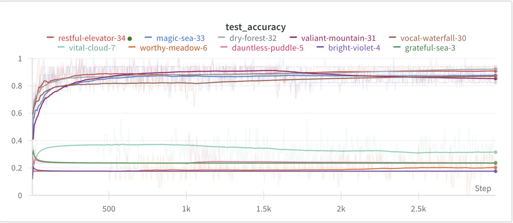

Further avenues for improving this model include incorporating data augmentations to reduce overfitting. Augmentations might consist of translations, flipping, adjusting intensities, etc. It's essential to pick augmentations that work within the context of the data.

I also recognise that my understanding of NIRx data could be more in-depth. There may be more imaginative ways to take advantage of the scientific context in this situation.

Finally, when it comes to using deep learning methods for healthcare-related problems, a certain level of explainability is required. I cannot provide an in-depth explanation for the decision-making made by this model. However, there are a few potential options to explore this:

- We could visualise the filters and feature maps, looking for insight into important features.
- We could also utilise a Class Activation Map. This technique could generate a heatmap indicating the most influential regions in the model's decision-making.
- Saliency maps also allow us to observe the contribution of each pixel to the model's decision by highlighting the most important pixels for classification.
- numerous other techniques.

Given the time constraints, I could not implement one of these methods, but I am confident I can quickly learn the necessary skills to achieve this.